# MASTER MODE : UE MDET : DYNAMIQUES EVOLUTIVES

— **Méthode graphique pour les zones de coexistence**

La plupart du temps, lorsqu’une invasion est possible, la population mutante va remplacer la population résidente. Cependant, la coexistence est possible. Les PIP permettent également de déterminer ces zones de coexistence (évolution polymorphique), en déterminant les combinaisons où :
$$s(x, y) > 0 \quad \text{et} \quad s(y, x) > 0$$
Pour cela, on va superposer les graphiques représentant $s(x, y)$ et $s(y, x)$ et déterminer où les zones où $s(x, y) ; s(y, x) > 0$ (i.e. superposition des zones noires) (Brännström et al., 2013). On applique cette méthode graphique au graphique **(b)** précedent :

> Le temps de calcul peut prendre quelques minutes

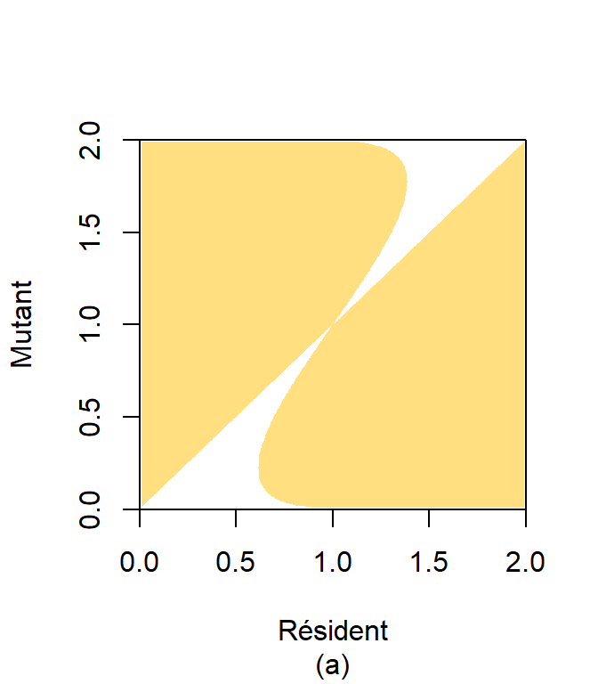

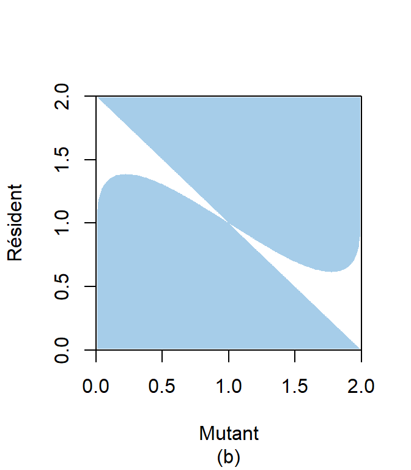

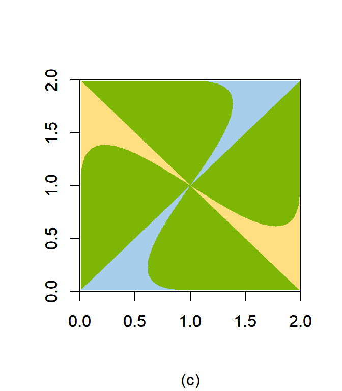

En couleur, les zones où $s(x, y) > 0$ [jaune, graphique **(a)**] et où $s(y, x) > 0$ [bleu, graphique **(b)**]. Le graphique **(c)** représente en vert les zones où $s(x, y); s(y, x) >0$. Cela représente donc les combinaisons de traits où les phénotypes $x$ et $y$ peuvent coexister.

# Modèle de compétition à n espèces —————————————————-

On généralise le modèle précédent à N espèces :

$$\frac{dn_i}{dt} = rn_i \Bigg[1 - \frac{\sum_{j = 1}^{N}a(x_i, x_j)
n_j}{K(x_i )} \Bigg]$$

Avec :

- $N$ : le nombre de phénotype en compétition (e.g. N = 30)
- $r$ : taux de croissance du phénotype $n_i$
- $n_i$ : la proportion de chaque phénotype $i$
- $x$ $\in [0, 2]^N$

On cherche à définir de façon matricielle le modèle tel que:

$$\frac{d\overline{n}}{dt} = r\overline{n}
* (1 - M \cdot \overline{n})$$
Avec $\overline{n}$ un vecteur contenant l’ensemble des effectifs de phénotypes et M la matrice des coefficients de compétitions.

La matrice M s’exprime :
$$M = \begin{pmatrix}
\frac{a_{11}}{K_1} & \frac{a_{21}}{K_2} & ... &
\frac{a_{N1}}{K_N} \\
\frac{a_{12}}{K_1} & \frac{a_{22}}{K_2} & ... &
\frac{a_{N2}}{K_N} \\
... & ... & \ddots & \vdots \\
\frac{a_{1N}}{K_1} & \frac{a_{2N}}{K_2} & ... &
\frac{a_{NN}}{K_N}
\end{pmatrix}
\quad \forall K_N \neq 0 \quad \text{et } N \text{ le nombre total de
phénotype}$$

D’un point de vue programmation, nous allons construire cette matrice $M$ avec 3 sous-matrice : $D$ contenant la distance des valeurs de traits $x_i - x_j$, $A$ la matrice de compétition contenant $a(x_i, x_j)$ et enfin $B$ contenant $\frac{1}{K_N}$. Soit :

$$\begin{align*}
D &= \begin{pmatrix}
0 & x_2 - x_1 & \dots & x_N - x_1 \\
x_1 - x_2 & 0 & \dots & x_N - x_2 \\
\dots & \dots & \ddots & \vdots \\
x_1 - x_N & x_2 - x_N & \dots & 0
\end{pmatrix}&&\\
&&\\
&&\\
A &= \begin{pmatrix}
a(x_1, x_1) & a(x_1, x_2) & \dots & a(x_1, x_N)\\
a(x_2, x_1) & a(x_2, x_2) & \dots & a(x_2, x_N) \\
\dots & \dots & \ddots & \vdots \\
a(x_N, x_1) & a(x_N, x_2) & \dots & a(x_N, x_N)
\end{pmatrix}
= e^{-\frac{D^2}{2 \sigma^2}}&&\\
&&\\
&&\\
B &= \begin{pmatrix}
\frac{1}{K(x_1)} & \frac{1}{K(x_2)} & ... & \frac{1}{K(x_N)}
\\
... & ... & \ddots & \vdots \\
\frac{1}{K(x_1)} & \frac{1}{K(x_2)} & ... & \frac{1}{K(x_N)}
\end{pmatrix}
\quad \forall K(x_N) \neq 0
\end{align*}$$

Soit la matrice $M$ :

$$M = A \times B$$

On obtient finalement l’équation différentielle ordinaire suivante :

$$\frac{d\overline{n}}{dt} = r\overline{n}
(1 - \overline{n} \cdot M ) \quad \small{\text{avec '} \cdot
\text{' un produit matriciel}}$$
Avec $\overline{n}$ le vecteur des proportions de départ de chaque phénotype :

$$\overline{n} =
\begin{pmatrix}
\overline{n}_1\\
\overline{n}_2\\
\dots\\
\overline{n}_N\\
\end{pmatrix} \quad \text{avec } N \text{ le nombre total de phénotype}$$

## Modélisation

#### — **Création de la matrice M**

```r
M_matrix <- function(N = N, xmin = xmin, xmax = xmax, sigma = sigma, k0 = k0, lambda = lambda){
  # DESCRIPTION
  #' @param N le nombre de phénotypes en compétition
  #' @param xmin valeur minimum du phénotype
  #' @param xmax valeur maximum du phénotype
  #' @param x la valeur des traits pour chacun de ces phénotypes
  #' @param sigma argument sigma de la fonction d'intensité de coefficient a(xi, xj)
  #' @param k0  valeur optimale d'utilisation de ressource de la fonction K(xN)
  #' @param lambda forme de la courbe d'utilisation de ressource de la fonction K(xN)
  #'
  #' @return La matrice M contenant les valeurs de a(xi, xj) / a(xi) [voir ci-dessus]


  # FONCTION
  x = seq(xmin, xmax, length.out = N)  # On répartit uniformément N fois les valeurs de trait entre xmin et xmax
  x0 = 1 # On fixe x0 à 1.

  # Matrice des traits D
  X = matrix(data = x, nrow = N, ncol = N, byrow = T)  # matrice des traits x1, ..., xN
  D = X - t(X)  # Matrice des xi - xj

  # Matrice de compétition A
  A = exp(-(D^2)/(2*(sigma)^2))  # Matrice des coefficients de compétition inter-traits

  # Matrice B contenant 1/KN
  K <- c()
  epsilon = 10^(-6)  # Pour ne pas avoir de 0 dans la matrice B
  for(trait in x){   # Valeur de K(xN) par trait
    K <- c(K, max( 0 + epsilon, k0 - lambda*((trait - x0))^2))
    }

  B_trans <-  matrix(data = K, nrow = N, ncol = N, byrow = T)  # Matrice K(xN)
  B <-  apply(X = B_trans, MARGIN = 2, FUN = function(x) 1/x)  # 1 / Matrice K(xN)

  # Matrice M
  M = A * B

  return(M)
}
```

On remarquera qu’ici, les phénotypes se répartissent de façon uniforme et symétrique autour de $x_0$.

#### — **Fonction équation différentielle**

```r
LV_trait <- function(t, n, params){
  # DESCRIPTION
  #' @param t le temps
  #' @param n la proportion initiale des phénotypes dans la population
  #' @param params liste des arguments : [M] la matrice M issue de M_matrix() et [r] le(s) taux de croissance des populations


  # FONCTION
  # Initialisaton
  r <- params[[1]]
  M <- params[[2]]

  # Sortie
  dn <-  r * n * (1 - n %*% M)

  return(list(dn))
}
```

#### — **Initialisation des paramètres**

On considérera 30 phénotypes en compétition variant de 0 à 2 de façon symétrique autour de $x_0 = 1$.

```r
# VALEURS INITITALES - M_matrix()
N = 30  # Nombre de phénotypes
xmin = 0  # Valeur minimum du trait
xmax = 2  # Valeur maximum du trait
k0 = 1  # Capacité d'acceuil maximum
lambda = 1
sigma = 0.5

M = M_matrix(   # Matrice M
  N = N,
  xmin = xmin,
  xmax = xmax,
  sigma = sigma,
  k0 = k0,
  lambda = lambda
)

# VALEURS INITITALES - LV_trait()
r = 1
params <- list(r = r, M = M)
n0 = rep(k0 / N, N)  # Proportions initiales
t = seq(0, 10000, 1)  # Temps
```

#### — **Résolution EDO**

On utilise la fonction ode() du package deSolve.

```r
sol <- ode(y = n0, times = t, func = LV_trait, parms = params)
```

## Visualisation

#### — Evolution des proportions des phénotypes en fonction du temps

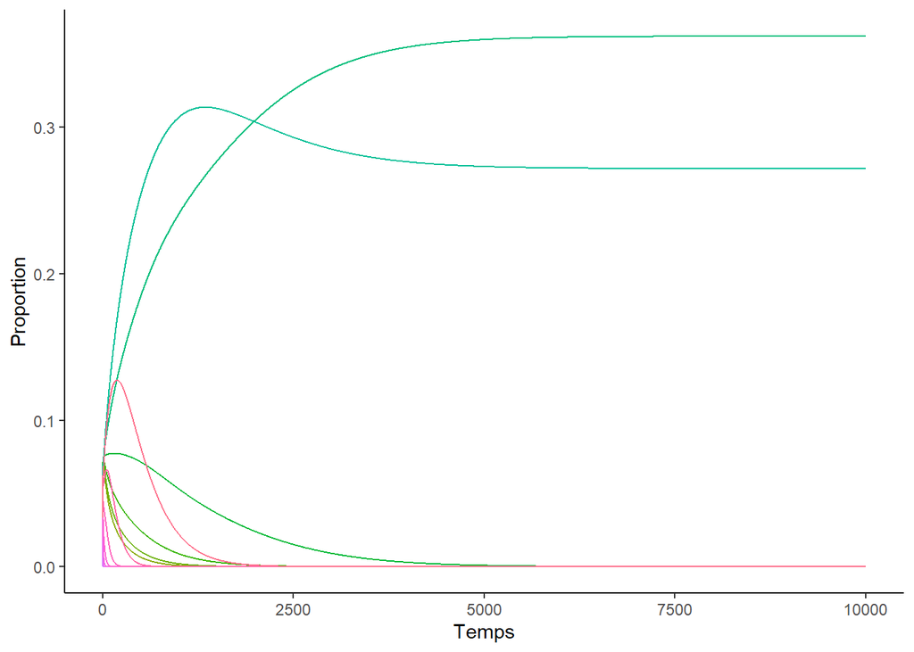

Les courbes peuvent se superposer (car symétrie autour de $x_0 = 1$). On réalise un autre schéma pour déterminer le temps d’extinction de chaque phénotype ainsi que leur persistance au temps final.

#### — Phénotypes “survivants”

On considera ici qu’un phénotype ayant une proportion de 0.01 a persisté.

```r
seuil <- 0.01  # Définition du seuil de persistance

# On définit 0 ou 1 la persistance au temps t de chaque phénotype
sol <- as.data.frame(sol)
persis <- apply(sol[2:(N+1)], MARGIN = 2, FUN = function(x) ifelse(x>=seuil, 1, 0))
persis <- cbind(sol["time"], persis)
persis <- pivot_longer(persis, cols = 2:(N+1), names_to = "Phenotype", values_to = "persis")
persis$Phenotype <- factor(persis$Phenotype, levels = 1:N)

# Temps d'exctinction de chaque phénotype
persis <- persis %>%
  group_by(Phenotype) %>%
  summarise(Persistance = sum(persis))

persis$survie <- ifelse(persis$Persistance != max(persis$Persistance), "0", "1")

# Tableau des persistances de chaque phénotype
rows <- seq_len(nrow(persis) %/% 3)
kable(list(persis[rows,1:3],
           "0"=rep("", max(rows)),
           persis[rows + 10,1:3],
           "1"=rep("", max(rows)),
           persis[rows + 20, 1:3]),
      caption = "Persistance de chaqe phénotype")
```

Persistance de chaqe phénotype

| Phenotype | Persistance | survie |
| --- | --- | --- |
| 1 | 1 | 0 |
| 2 | 1 | 0 |
| 3 | 3 | 0 |
| 4 | 6 | 0 |
| 5 | 12 | 0 |
| 6 | 34 | 0 |
| 7 | 105 | 0 |
| 8 | 324 | 0 |
| 9 | 1269 | 0 |
| 10 | 10001 | 1 |

| x |
| --- |

| Phenotype | Persistance | survie |
| --- | --- | --- |
| 11 | 10001 | 1 |
| 12 | 2913 | 0 |
| 13 | 941 | 0 |
| 14 | 514 | 0 |
| 15 | 394 | 0 |
| 16 | 394 | 0 |
| 17 | 514 | 0 |
| 18 | 941 | 0 |
| 19 | 2913 | 0 |
| 20 | 10001 | 1 |

| x |
| --- |

| Phenotype | Persistance | survie |
| --- | --- | --- |
| 21 | 10001 | 1 |
| 22 | 1269 | 0 |
| 23 | 324 | 0 |
| 24 | 105 | 0 |
| 25 | 34 | 0 |
| 26 | 12 | 0 |
| 27 | 6 | 0 |
| 28 | 3 | 0 |
| 29 | 1 | 0 |
| 30 | 1 | 0 |

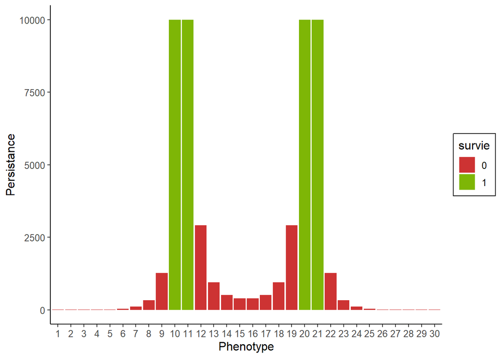

## Modulation du paramètre sigma

On explore comment les variations du paramètre sigma (modulant l’intensité de la compétition) vont impacter le nombre de phénotypes co-existant en fin de simulation. Nous resterons à un seuil de 1% pour la persistance au temps final, N = 30 espèces et fixeront les mêmes valeurs que précédemment pour les autres paramètres.  
Nous testerons 150 valeurs de sigma comprises entre 0.01 et 1.5.

> Le temps de calcul peut prendre quelques minutes

```r
# Valeur de sigma modifié
sigma <- seq(0.01, 1.5, 0.01)

# Boucle de la matrice M et de l'EDO pour calculer les nouvelles valeurs
data_sigma <- data.frame(sigma = NULL, survie_nb = NULL)

ligne <- 1  # incrémention ligne
for(sigma_modif in sigma){
  # EDO par valeur de sigma
  M <- M_matrix(
    N = N,
    xmin = xmin,
    xmax = xmax,
    sigma = sigma_modif,
    k0 = k0,
    lambda = lambda
  )
  params <- list(r, M)
  sol <- ode(y = n0, times = t, func = LV_trait, parms = params)

  # On stocke le nombre de survivant associé à la valeur de sigma
  data_sigma[ligne, "sigma"] <- sigma_modif
  data_sigma[ligne, "survie_nb"] <- sum(sol[nrow(sol), 2:(N+1)] >= seuil)

  ligne = ligne + 1
}
```

#### —- Visualisation

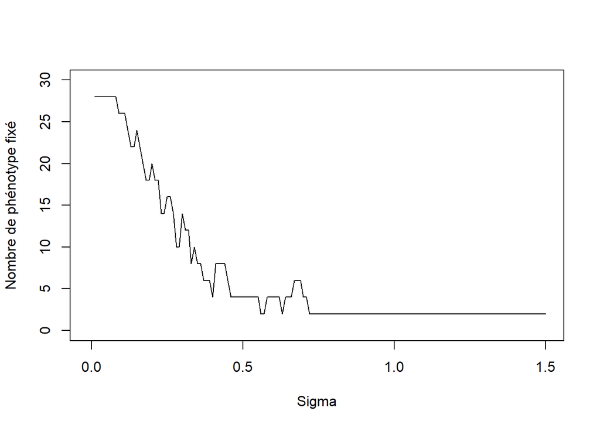